# Parte 3: Slot Machine

## Capítulo 10: Velocidad

### Vectorized code

Se pueden observar los siguientes códigos. El primero no está vectorizado. Usa un loop para manipular cada individio del vector individualmente

```r
abs_loop <- function(vec){
  for (i in 1:length(vec)) {
    if (vec[i] < 0) {
      vec[i] <- -vec[i]
    }
  }
  vec
}
```

Usa logical subsetting para manipular cada elemento del vector al mismo tiempo

```r
abs_sets <- function(vec){
  negs <- vec < 0
  vec[negs] <- vec[negs] * -1
  vec
}

negs <- vec < 0
```

```
Error: objeto 'vec' no encontrado
```

Lo que R ejecuta más rápidamente es lo siguiente

logical tests, subsetting, and element-wise execution

Comprobemos el cambio en velocida de la siguiente forma

```r
long <- rep(c(-1, 1), 5000000) #rep repeats a value, or vector of values, many times To use rep, give it a vector of values and then the number of times to repeat the vector. R will return the results as a new, longer vector.

system.time(abs_loop(long))
```

```
   user  system elapsed
   0.78    0.00    0.86
```

```r
system.time(abs_sets(long))
```

```
   user  system elapsed
   0.29    0.08    0.37
```

Algunas funciones ya vienen optimizadas, como el caso de la función abs, que realiza lo mismo que las dos anteriores

```r
system.time(abs(long))
```

```
   user  system elapsed
   0.05    0.00    0.04
```

### How to Write Vectorized Code

Vectorized code is easy to write in R because most R functions are already vectorized. Code based on these functions can easily be made vectorized and therefore fast. To create vectorized code:

1. Use vectorized functions to complete the sequential steps in your program.
2. Use logical subsetting to handle parallel cases. Try to manipulate every element in a case at once

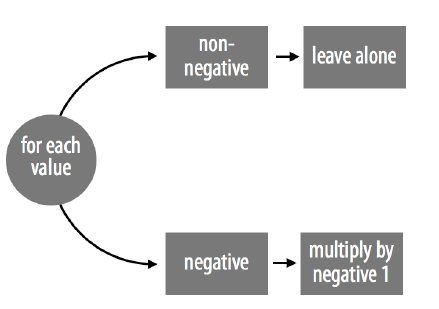

```r
vec <- c(1, -2, 3, -4, 5, -6, 7, -8, 9, -10)
vec < 0
```

```
 [1] FALSE  TRUE FALSE  TRUE FALSE  TRUE FALSE  TRUE FALSE  TRUE
```

```r
vec[vec < 0]
```

```
[1]  -2  -4  -6  -8 -10
```

```r
vec[vec < 0] * -1
```

```
[1]  2  4  6  8 10
```

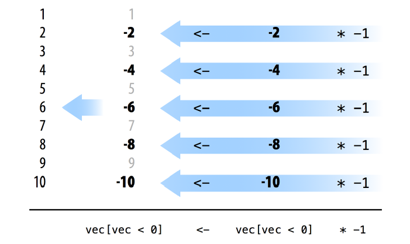

#### Ejercicio:

Vectorizar el siguiente código:

```r
change_symbols <- function(vec){
  for (i in 1:length(vec)){
  if (vec[i] == "DD") {
      vec[i] <- "joker"
    } else if (vec[i] == "C") {
      vec[i] <- "ace"
    } else if (vec[i] == "7") {
      vec[i] <- "king"
    }else if (vec[i] == "B") {
      vec[i] <- "queen"
    } else if (vec[i] == "BB") {
      vec[i] <- "jack"
    } else if (vec[i] == "BBB") {
      vec[i] <- "ten"
    } else {
      vec[i] <- "nine"
    }
  }
  vec
}
vec <- c("DD", "C", "7", "B", "BB", "BBB", "0")
change_symbols(vec)
```

```
[1] "joker" "ace"   "king"  "queen" "jack"  "ten"   "nine"
```

```r
## "joker" "ace" "king" "queen" "jack" "ten" "nine"
many <- rep(vec, 1000000)
system.time(change_symbols(many))
```

```
   user  system elapsed
   9.26    0.09    9.58
```

```r
## user system elapsed
## 30.057 0.031 30.079
```

Vectorizado

```r
vec[vec == "DD"]
```

```
[1] "DD"
```

```r
## "DD"
vec[vec == "C"]
```

```
[1] "C"
```

```r
## "C"
vec[vec == "7"]
```

```
[1] "7"
```

```r
## "vec[vec == "B"]
## "B"
vec[vec == "BB"]
```

```
[1] "BB"
```

```r
## "BB"
vec[vec == "BBB"]
```

```
[1] "BBB"
```

```r
## "BBB"
vec[vec == "0"]
```

```
[1] "0"
```

```r
## "0"
```

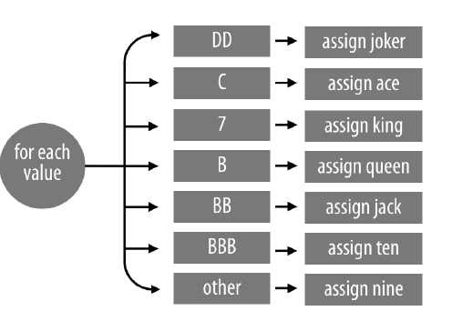

entonces

```r
change_vec <- function (vec) {
vec[vec == "DD"] <- "joker"
vec[vec == "C"] <- "ace"
vec[vec == "7"] <- "king"
vec[vec == "B"] <- "queen"
vec[vec == "BB"] <- "jack"
vec[vec == "BBB"] <- "ten"
vec[vec == "0"] <- "nine"
vec
}
system.time(change_vec(many))
```

```
   user  system elapsed
   0.39    0.08    0.47
```

```r
## user system elapsed
## 1.994 0.059 2.051
```

```r
change_vec2 <- function(vec){
tb <- c("DD" = "joker", "C" = "ace", "7" = "king", "B" = "queen", "BB" = "jack", "BBB" = "ten", "0" = "nine")
unname(tb[vec])
}
system.time(change_vec(many))
```

```
   user  system elapsed
   0.39    0.08    0.48
```

```r
## user system elapsed
## 0.687 0.059 0.746
```